# Datenvisualisierung mit R

Gestaltungsarten – die “Geome”

Armin Schäfer

schaefer@politik.uni-mainz.de

15.05.2025

## Wo wir waren

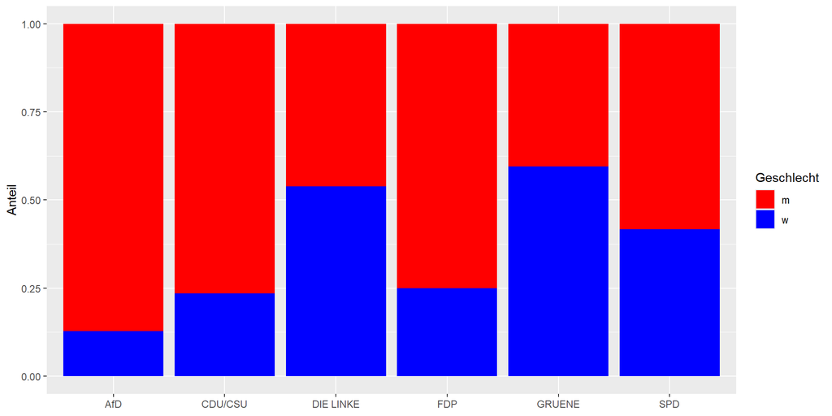

```r
ggplot(data = fraktionen_long,
       aes(x = Partei, y = Anzahl, fill = Geschlecht))+
  geom_col(position = "fill")+
  scale_fill_manual(values = c("red", "blue"))+
  labs(x = NULL, y = "Anteil")
```

Wie sind die Balken angeordnet?

## Reihenfolge der Balken manuell bestimmen – `fct_relevel()`

Variablen, die nicht Zahlen, sondern Wörter enthalten, sind Faktoren. Standardmäßig werden diese Faktoren **alphabetisch sortiert**. Deshalb sind die Balken in der Grafik bislang ebenfalls alphabetisch angeordnet.

Um dies zu ändern, verändern wir mithilfe von `mutate()` und `fct_relevel()` aus der Bibliothek `forcats` die Reihenfolge der Parteien im Datensatz.<sup>1</sup>

```r
fraktionen_long <- fraktionen_long %>%  # in diesem Fall überschreiben wir den Datensatz
  mutate(Partei = fct_relevel(Partei,
                             "DIE LINKE", "GRUENE", "SPD",
                             "FDP", "CDU/CSU", "AfD"))
```

[^1]: `forcats` muss nicht extra installiert werden, weil es Teil der `tidyverse`-Bibliothek ist.

## Neu sortiert!

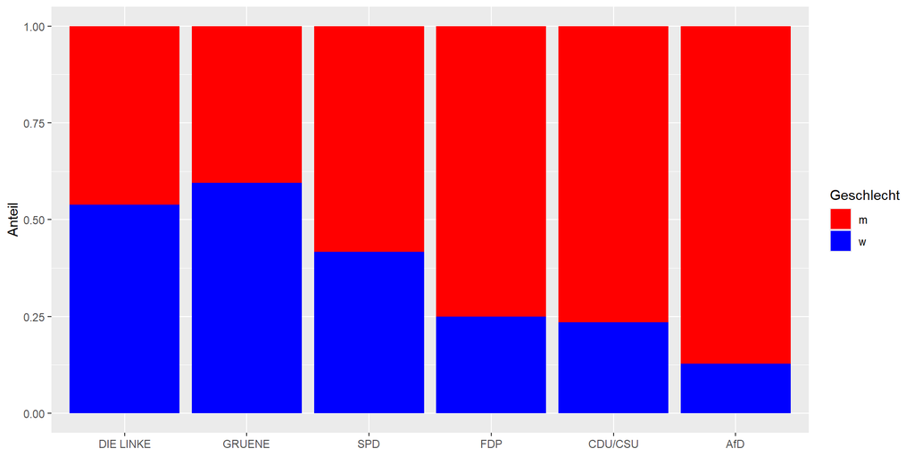

```r
ggplot(data = fraktionen_long,
       aes(x = Partei, y = Anzahl, fill = Geschlecht))+
  geom_col(position = "fill")+
  scale_fill_manual(values = c("red", "blue"))+
  labs(x = NULL, y = "Anteil")
```

## `fct_relevel()` vs `fct_reorder()`

Mit `fct_relevel()` können wir jede beliebige Reihenfolge festlegen. Im Beispiel habe ich mich an der Sitzordnung im Bundestag orientiert. Häufig möchten wir aber eine **inhaltliche Aussage** treffen und die Balken mithilfe von Werten aus einer anderen Variable sortieren – beispielsweise anhand des Frauenanteils in den Fraktionen. Hierfür verwenden wir `fct_reorder()` ebenfalls aus der `forcats`-Bibliothek.

## Reihenfolge der Balken ändern – `fct_reorder()`

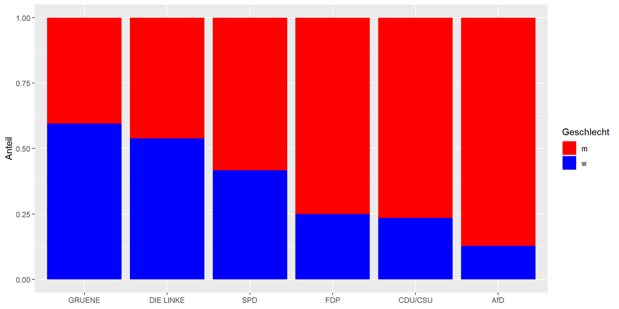

```r
fraktionen %>%
  mutate(percfem = w/(m + w)) %>%
  pivot_longer(-c("Partei", "percfem", "id"), names_to = "Geschlecht", values_to = "Anzahl") %>%
ggplot(aes(x = fct_reorder(Partei, -percfem), y = Anzahl, fill = Geschlecht))+
  geom_col(position = "fill")+
  scale_fill_manual(values = c("red", "blue"))+
  labs(x = NULL, y = "Anteil")
```

## Farben der Parteien hinzufügen

Um die Farben der Parteien festzulegen, kopieren wir Farbcodes von dieser [Github-Seite](https://gist.github.com/Pepo/1bf1b2d47a728e6c69d8b611a4063075) und fügen sie in einen neuen Vektor sein. Verwenden Sie diesen Vektor nun, um die Farben im Diagramm zu ändern. Wie gehen Sie vor?

```r
parteifarbe <- c('#ff748c', '#1AA037', '#E3000F',
                 '#FFEF00', '#000000', '#0489DB')
```

**Important**

Die Reihenfolge der Farben muss den Levels der Variable Partei im Datensatz fraktionen_long entsprechen!

## Parteifarben

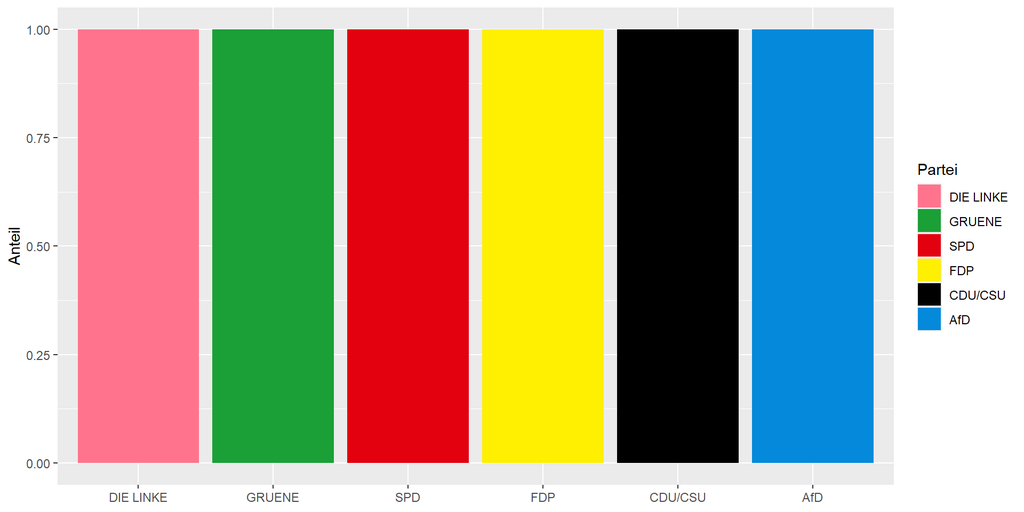

```r
ggplot(data = fraktionen_long,
       aes(x = Partei,
           y = Anzahl,
           fill = Partei))+
  geom_col(position = "fill")+
  scale_fill_manual(values = parteifarbe)+
  labs(x = NULL,
       y = "Anteil")
```

Verwenden Sie nun `scale_alpha_manual()`, um unterschiedliche Transparenzgrade für Frauen und Männer zu verwenden.

## Parteifarben und Transparenz

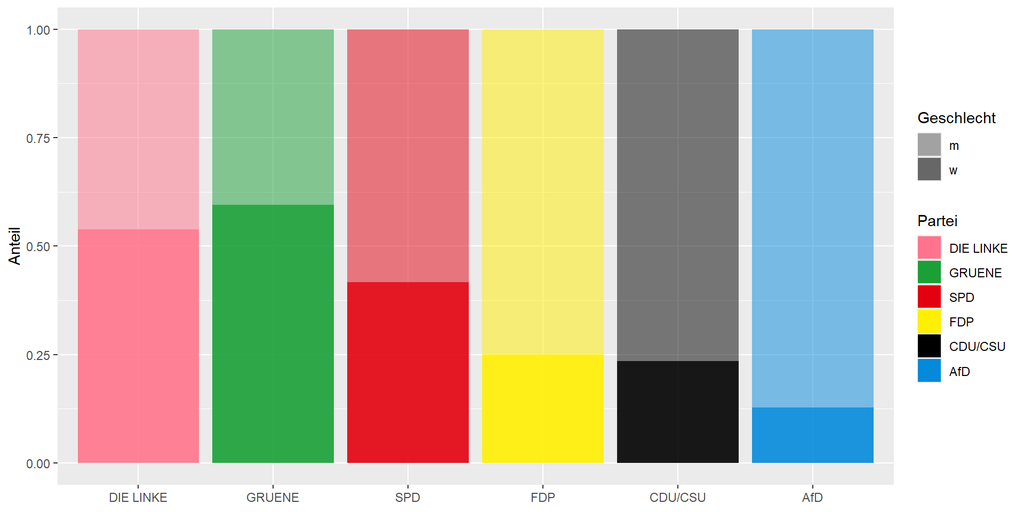

```r
ggplot(data = fraktionen_long,
       aes(x = Partei, y = Anzahl,
           fill = Partei, alpha = Geschlecht))+
  geom_col(position = "fill")+
  scale_fill_manual(values = parteifarbe)+
  scale_alpha_manual(values = c(0.5, 0.9))+
  labs(x = NULL, y = "Anteil")
```

## Fast geschafft!

Um die Farben besser sichtbar zu machen, ändern wir das Erscheinungsbild der Grafik. Das geschieht über `theme`. Unter anderem folgende Designs sind verfügbar:

`theme_bw()`

`theme_classic()`

`theme_minimal()`

`theme_dark()`

## Minimalistisches Erscheinungsbild

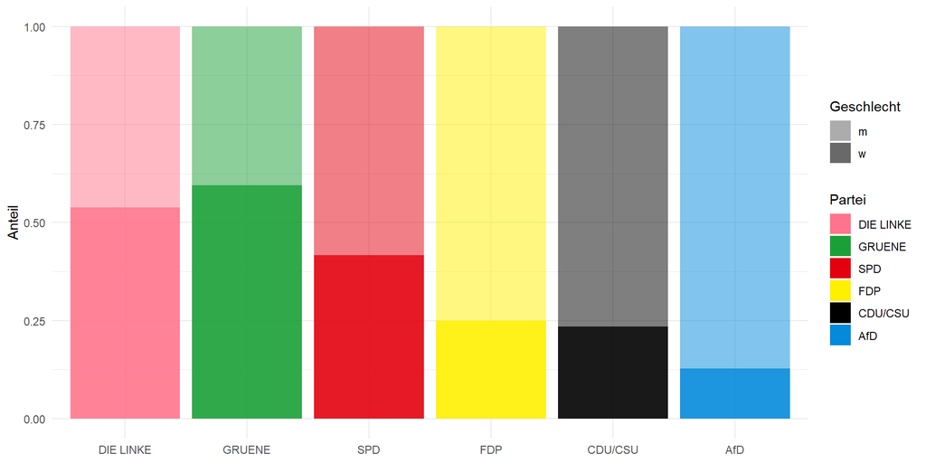

```r
ggplot(data = fraktionen_long, aes(x = Partei, y = Anzahl,
                                   fill = Partei, alpha = Geschlecht))+
  geom_col(position = "fill")+
  scale_fill_manual(values = parteifarbe)+
  scale_alpha_manual(values = c(0.5, 0.9))+
  labs(x = NULL, y = "Anteil")+
  theme_minimal()
```

## Letzter Schritt

Wir entfernen mit dem Befehl `guides()` die überflüssige Legende, in der die Parteinamen auftauchen.<sup>1</sup>

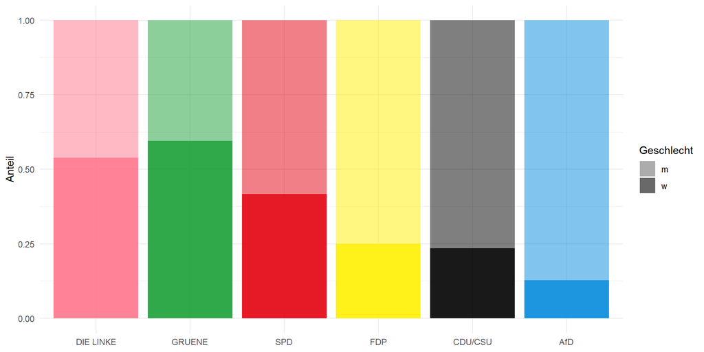

```r
ggplot(data = fraktionen_long,
       aes(x = Partei,
           y = Anzahl,
           fill = Partei,
           alpha = Geschlecht))+
  geom_col(position = "fill")+
  scale_fill_manual(values = parteifarbe)+
  scale_alpha_manual(values = c(0.5, 0.9))+
  labs(x = NULL, y = "Anteil")+
  theme_minimal()+
  guides(fill = FALSE)
```

[^2]: Was passiert, wenn Sie in der letzten Zeile “fill” durch “alpha” ersetzen?

# Weitere Darstellungsarten

## Grammar of Graphics

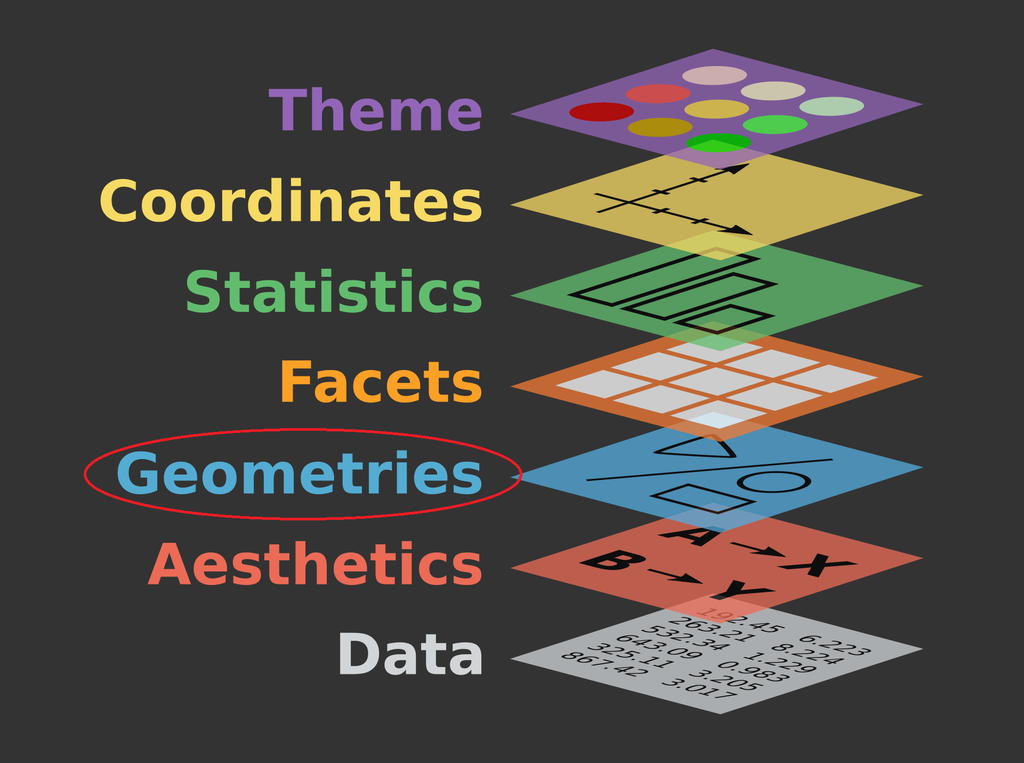

## Weitere “Geome”

Wir werden verschiedene Möglichkeiten kennenlernen, *Verteilungen* darzustellen. Statt nur den Mittelwert abzubilden, wollen wir alle Werte einer Variable erfassen. Dazu schauen wir uns folgende Darstellungsarten an:

`geom_histogram()`

`geom_density()`

`geom_point()`

`geom_jitter()`

`geom_boxplot()`

`geom_violin()`

## Excel-Daten einlesen

Bitte laden Sie die Datei bundestag.xlsx aus dem Order “Datensätze” in Moodle herunter und speichern Sie diese in dem Ordner “data”. Laden Sie ihn mit dem Befehl `import()`:

```r
bundestag <- import(here("data", "bundestag.xlsx"))
```

## Welche Informationen enthält der Datensatz?

```
'data.frame':   727 obs. of  7 variables:
 $ id         : num  1 2 3 4 5 6 7 8 9 10 ...
 $ vornamen   : chr  "Sanae" "Valentin Christian" "Knut Friedrich Alexander" "Katja" ...
 $ name       : chr  "Abdi" "Abel" "Abraham" "Adler" ...
 $ partei     : chr  "SPD" "FDP" "CDU/CSU" "FDP" ...
 $ geburtsjahr: num  1986 1991 1966 1974 1976 ...
 $ geschlecht : chr  "w" "m" "m" "w" ...
 $ alter      : num  35 30 55 47 45 28 39 31 53 40 ...
```

## Altersverteilung: Histogramm

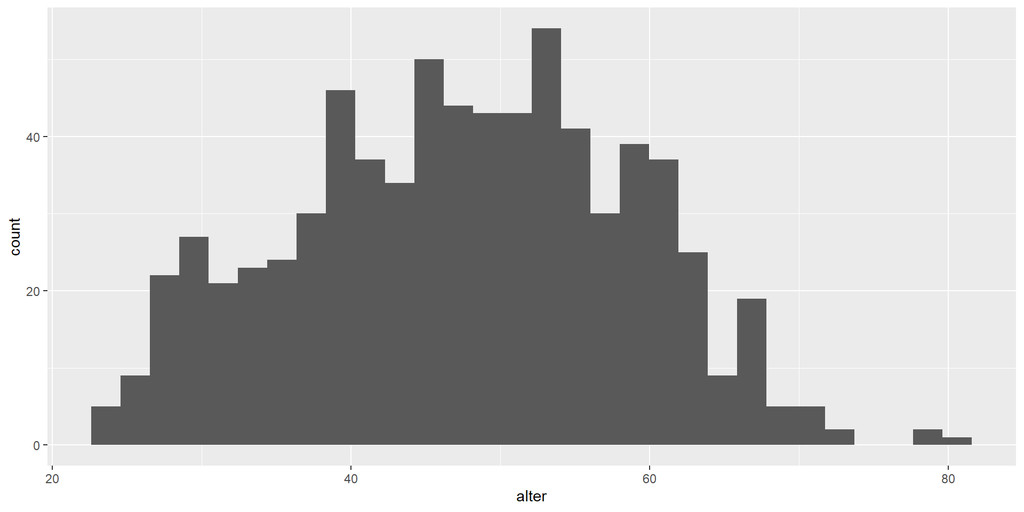

```r
ggplot(data = bundestag, aes(x = alter))+
  geom_histogram()
```

Verändern Sie nun die Code, um Frauen und Männer getrennt voneinander darzustellen.

## Altersverteilung: Histogramm

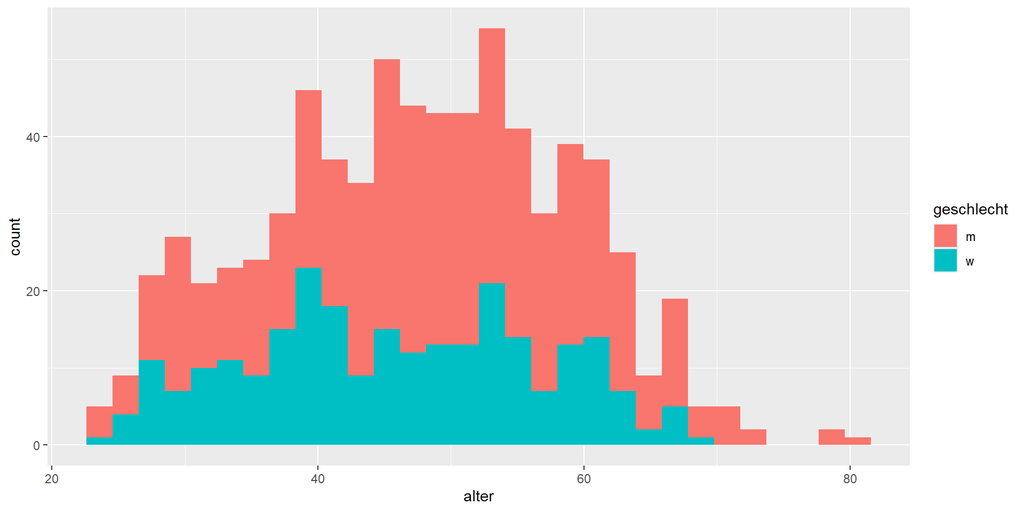

```r
ggplot(data = bundestag, aes(x = alter, fill = geschlecht))+
  geom_histogram()
```

Färben Sie zusätzlich die Außenlinien der Balken weiß ein.

## Altersverteilung: Histogramm

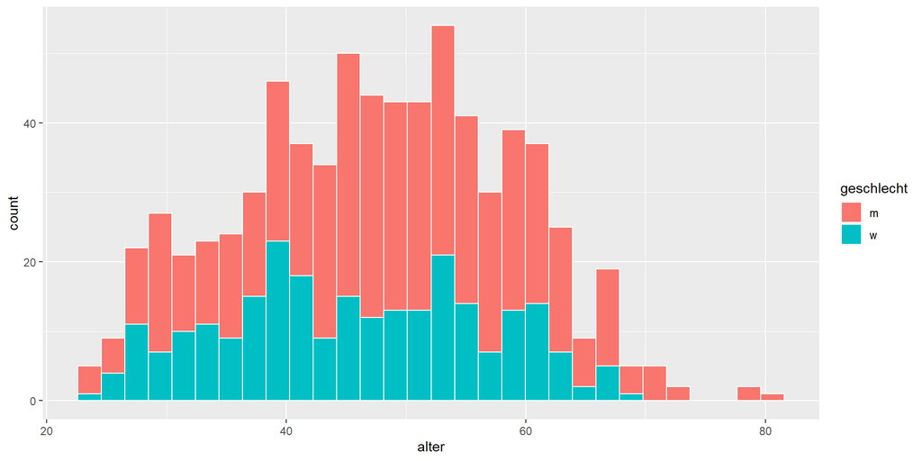

```r
ggplot(data = bundestag, aes(x = alter, fill = geschlecht))+
  geom_histogram(color = "white")
```

Vielleicht lieber unterschiedliche Farben für die Außenlinien nach Geschlecht verwenden und die Balken selbst weiß einfärben? Als Linienfarbe wählen wir rot und blau.

## Altersverteilung: Histogramm

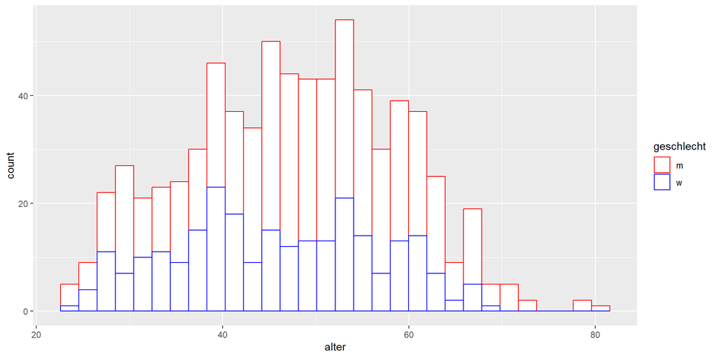

```r
ggplot(data = bundestag, aes(x = alter, color = geschlecht))+
  geom_histogram(fill = "white") +
  scale_color_manual(values = c("red", "blue"))
```

## Histogramm: Balkenbreite

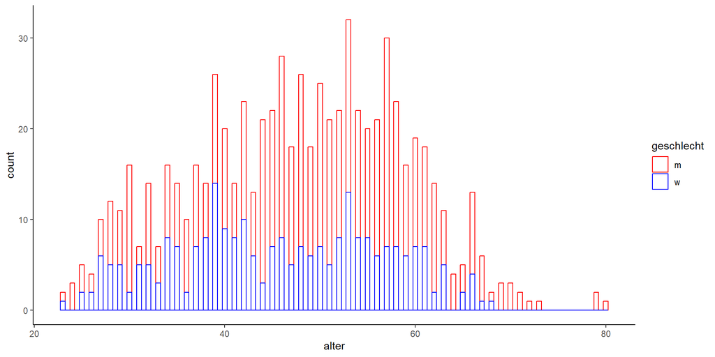

```r
ggplot(data = bundestag, aes(x = alter, color = geschlecht))+
  geom_histogram(fill = "white", binwidth = 0.5) +
  scale_color_manual(values = c("red", "blue"))+
  theme_classic()
```

## Facets

Häufig ist es sinnvoll, nicht alle Gruppen in einer Abbildung darzustellen, sondern **eine Abbildung pro Gruppe** zu bilden. Dies geschieht über eine weitere Schicht, die wir dem Code hinzufügen.

Die Zeile `facet_wrap(~ partei)` erzeugt ein Diagramm pro Partei. Nutzen Sie diese Zeile, um die Alterszusammensetzung der Abgeordneten getrennt für die Parteien darzustellen. Auf die Unterscheidung zwischen Frauen und Männern verzichten wir.

## Facets

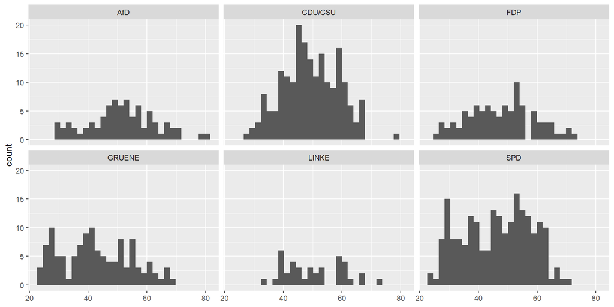

```r
ggplot(data = bundestag, aes(x = alter))+
  geom_histogram()+
  labs(x = NULL)+
  facet_wrap(~ partei)
```

## Density

Lesen Sie sich zunächst die Beschreibung unter `?geom_density` durch. Was wird dargestellt?

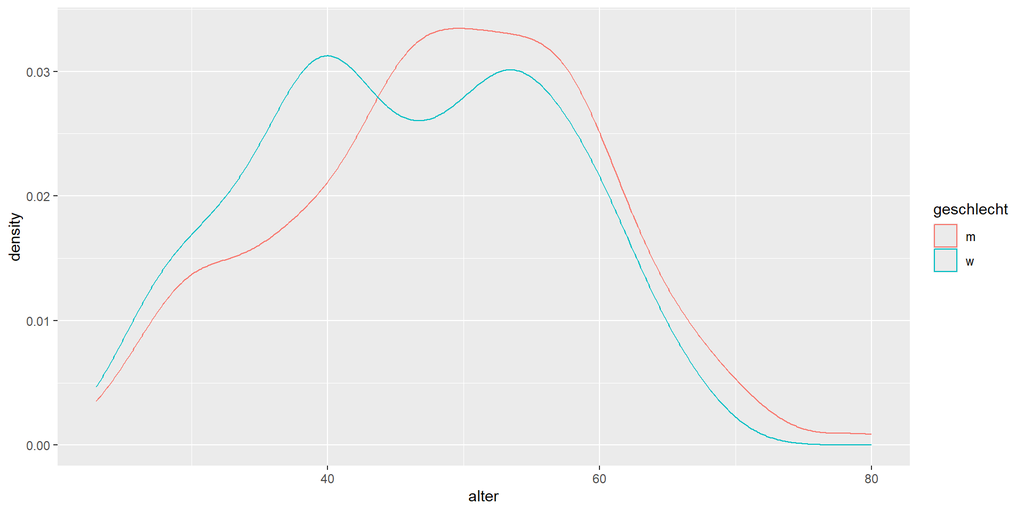

```r
ggplot(data = bundestag, aes(x = alter, color = geschlecht))+
geom_density()
```

Experimentieren Sie nun mit `fill` und `alpha`.

## Density

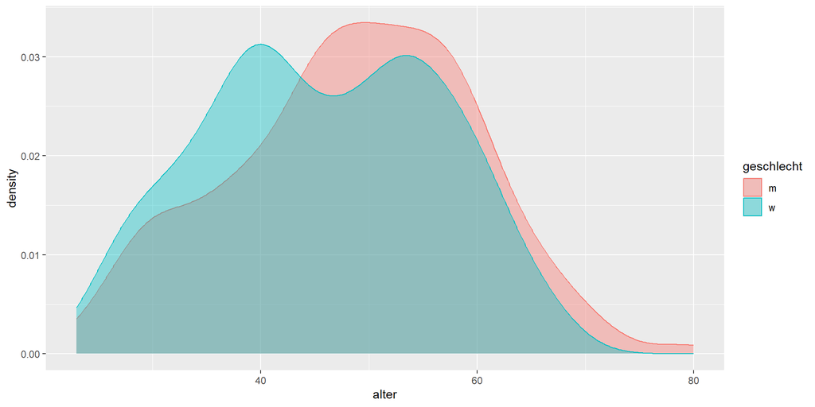

```r
ggplot(data = bundestag, aes(x = alter, fill = geschlecht, color = geschlecht))+
  geom_density(alpha = 0.4)
```

## Einschub: Die Beschriftung der x-Achse ändern

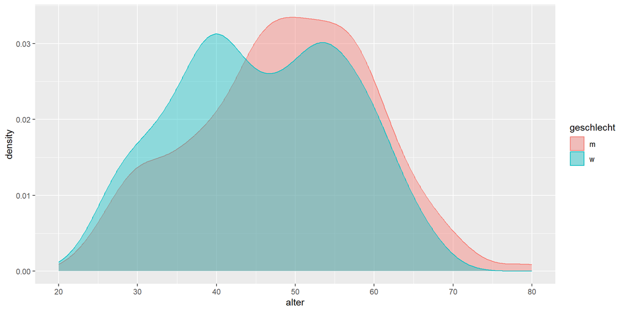

```r
ggplot(data = bundestag, aes(x = alter, fill = geschlecht, color = geschlecht))+
  geom_density(alpha = 0.4)+
  scale_x_continuous(limits = c(20,80), breaks = c(20,30,40,50,60,70,80))
```

## Die Beschriftung der x-Achse ändern: Alternative

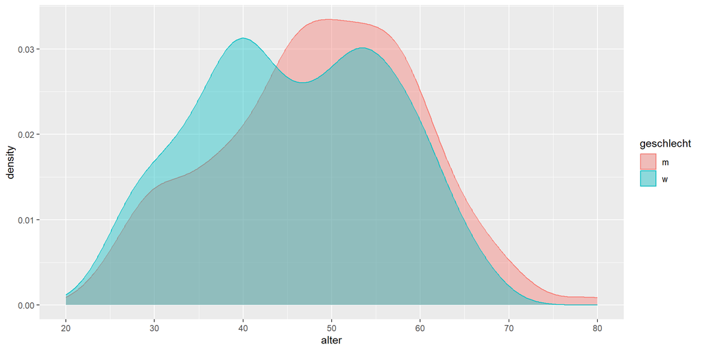

```r
ggplot(data = bundestag, aes(x = alter, fill = geschlecht, color = geschlecht))+
  geom_density(alpha = 0.4)+
  scale_x_continuous(limits = c(20,80), breaks = seq(20, 80, by = 10))
```

## Mehrere Gruppen

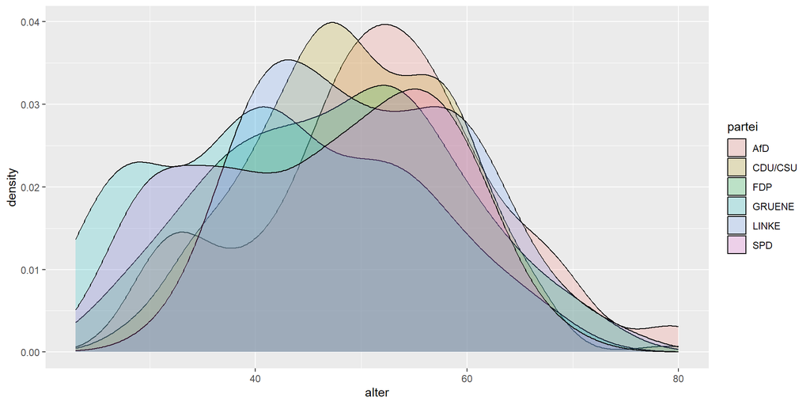

```r
ggplot(data = bundestag, aes(x = alter, fill = partei))+
geom_density(alpha = 0.2)
```

Schön bunt, aber schwierig zu lesen…

## Verteilung in Gruppen

Warum ist das keine nützliche Darstellungsart?

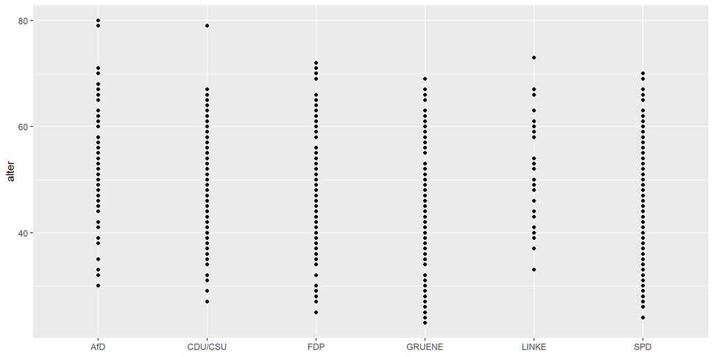

```r
ggplot(data = bundestag, aes(x = partei, y = alter))+
  geom_point()+
  labs(x = NULL)
```

## Verteilung in Gruppen – `geom_point()`

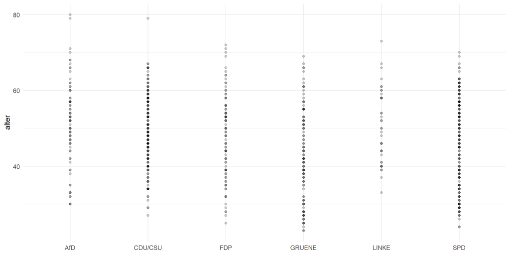

```r
ggplot(data = bundestag, aes(x = partei, y = alter))+
  geom_point(alpha = 0.2)+
  labs(x = NULL)+
  theme_minimal()
```

Viele Punkte überlagern sich. Das ist nicht ideal. Ersetzen Sie `geom_point()` durch `geom_jitter()`.

## Verteilung in Gruppen – `geom_jitter()`

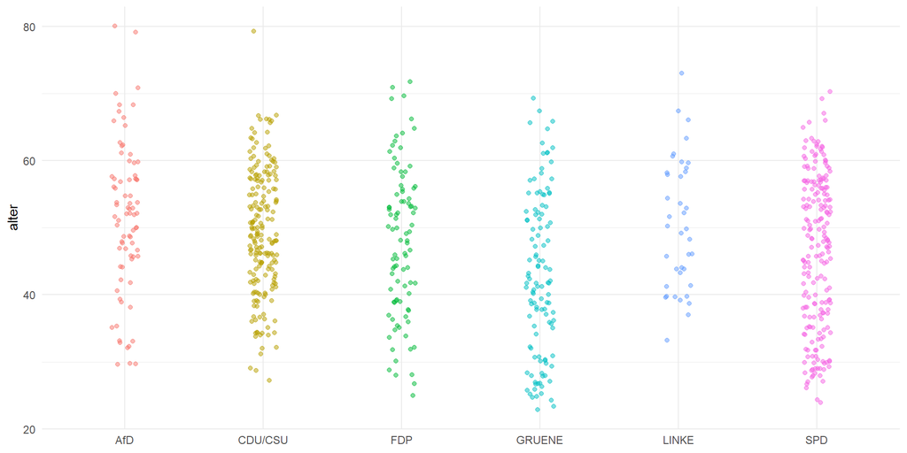

```r
ggplot(data = bundestag, aes(x = partei, y = alter, color = partei))+
  geom_jitter(alpha = 0.5, width = 0.1)+ # 'width' bestimmt, wie sehr die Punkte streuen.
  labs(x = NULL)+
  theme_minimal()+
  guides(color = FALSE)
```

Wir kommen darauf zurück.

Fortsetzung am 05.06.2025!

Datenvisualisierung